# tmpsxm69b0g

## 思想剧场：心灵训练营开营日

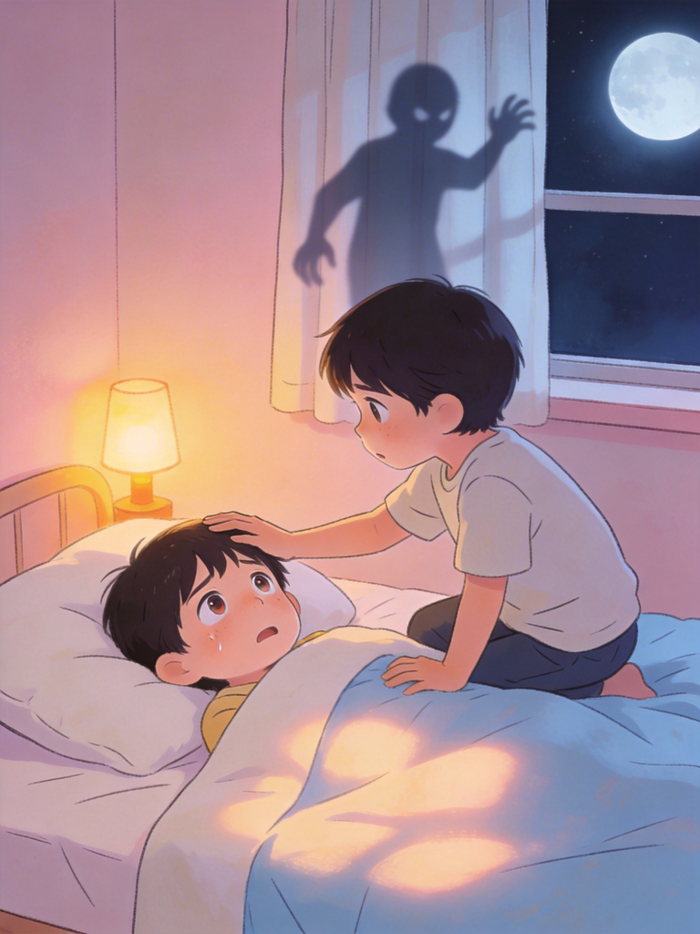

## 第一营区：良知信号站（王阳明）

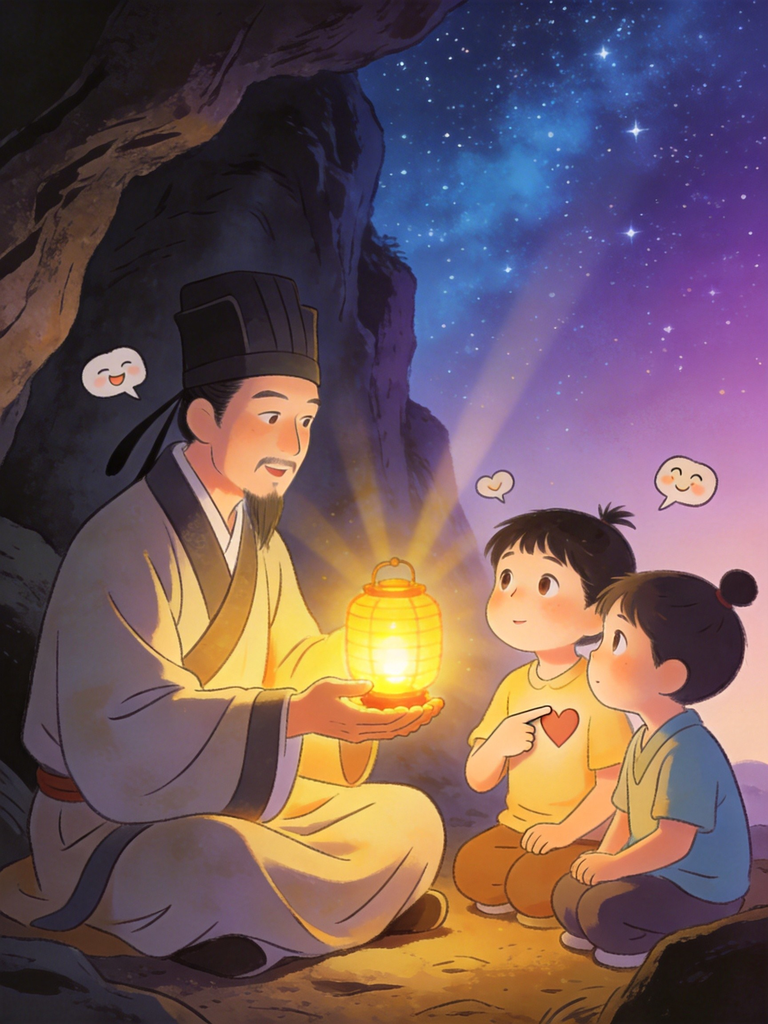

## 第二营区：不二法门屋（禅宗）

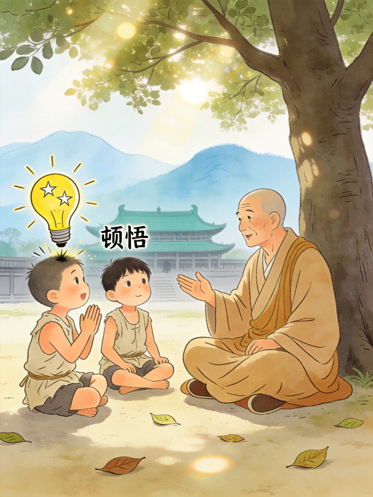

## 第三营区：木鸡修炼场（庄子）

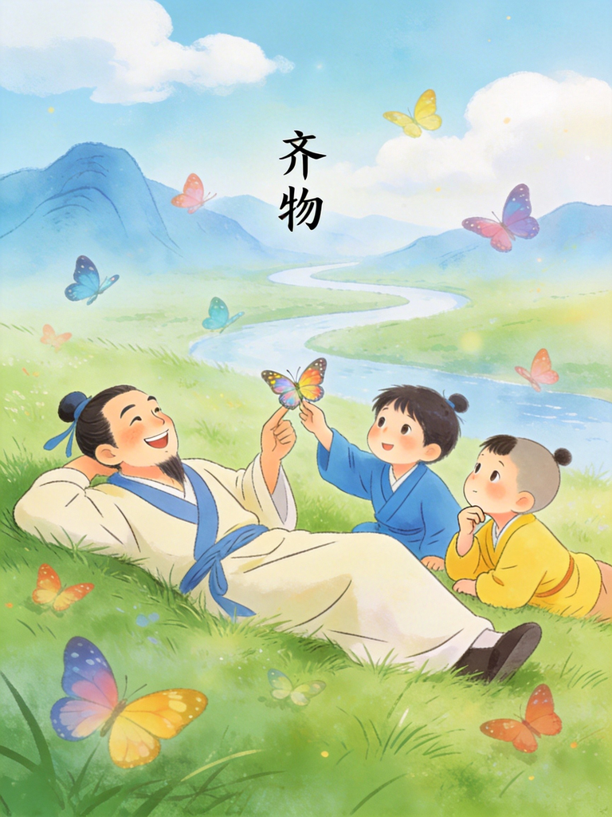

# 第六章：心里害怕怎么办？（王阳明、禅宗、庄子）

**时间**：周六上午9点  
**地点**：学校心理活动室“心灵探险基地”  
**人物**：  
- **小星**（10岁，想象力丰富，最近总做噩梦）  
- **小宇**（11岁，学霸，害怕考试失误）  
- **心灵导师**（活动主持人）  
- **王阳明**（明朝心灵探险家）  
- **慧能大师**（禅宗顿悟教练）  
- **庄子**（逍遥游俱乐部创始人） **【场景】**  
活动室墙上贴着“情绪地图”“勇气勋章榜”，中间摆着三个特色帐篷：  
1. **良知信号站**（王阳明帐篷，内有“三问清单”手卡）  
2. **不二法门屋**（禅宗帐篷，挂着一面“情绪云朵观察镜”）  
3. **木鸡修炼场**（庄子帐篷，放着呼吸计数沙漏） **心灵导师**：欢迎来到心灵训练营！今天我们有三位古代心灵探险家，带你们和“害怕”做朋友。谁先分享最近的害怕体验？

**小星**（举手，声音小）：我…我最近总怕黑，晚上觉得窗帘后面有人。 **小宇**：我怕下周期中考试，虽然复习了，但担心发挥失常。

**王阳明**（从良知信号站走出，温和地）：怕，不是敌人，是**良知在敲门**。你们想不想知道这扇门后有什么？ **小星**：（主动提问1）良知是什么？它怎么敲门？

**王阳明**：问得好！良知就是你

**内心自带的道德GPS**（心即理）。怕黑，是它在提醒“注意安全”；怕考砸，是它在提醒“你想做好”。信号收到了，下一步呢？ **小宇**：（质疑反驳1）可是怕就是难受啊，信号来了我更紧张了，怎么办？

**王阳明**：所以不能只收信号，要

**解码行动**。这就是“知行合一”——真知道火烫手，自然就不摸；真知道怕是什么信号，自然就会做点什么。来，我们进站练习！ — ### 古人故事：龙场悟道之夜 **背景**：王阳明35岁时，因得罪太监被贬贵州龙场，那里荒无人烟，毒虫遍地，仆人都病倒了。

**那个夜晚**： 1.

**极致的怕**：孤独、疾病、死亡威胁——所有怕聚在一起。 2.

**关键的翻转**：他问自己：“如果圣人（比如孔子）在这里，会怎么面对？” 3.

**顿悟瞬间**：他突然明白：“圣人之道，吾性自足！”——道德智慧不在外面，就在我心里。怕不是来摧毁我的，是来唤醒我的良知的。

**儿童版启示**： - 怕到极点，可能是突破的起点。 - 问问你心里的“良知GPS”：这时候，最好的我会怎么做？ - 你不是一个人在怕，古代探险家也怕过，而且把怕变成了智慧燃料。 ### 核心工具：致良知 = 擦拭心里的明镜

**王阳明**：每个人心里都有一面明镜，能照出是非对错。但私欲、焦虑就像灰尘，让镜子模糊。“致良知”就是不断擦拭，让镜子保持明亮。

**小星**：（主动提问2）怎么擦？用抹布吗？

**王阳明**（笑）：用“事上磨练”！每次害怕都是一次擦拭机会。我设计了三步擦镜法： #### 擦镜第一步：三问清单（给信号解码） 1. **我怕的到底是什么？**（具体化：“怕黑”→“怕黑暗中看不清危险”） 2. **这是事实还是我想象？**（验证：“有人” vs “我觉得有人”） 3. **最坏情况我能承受吗？**（99%的回答是“能”） **小宇**：（立场选择）我选考试怕失误。最坏情况是考不及格…嗯，我能承受，因为可以补考。

**王阳明**：很好！你已经在擦了。镜子亮了一度。

**小星**：（立场选择）那我选怕黑。最坏情况是…窗帘后面真的有人？但我知道检查过就没有，所以能承受。

**小星**补充：其实我上周做噩梦，梦见被影子追，醒来后心跳好快。这算良知信号吗？ **王阳明**：当然！那是良知在提醒“注意安全边界”。你可以用三问清单解码噩梦信号。 #### 擦镜第二步：良知行动（做一件小事） - 怕黑？开小夜灯 + 对自己说：“这是我的房间，很安全。” - 怕考试？做一道典型题 + 记下“这道题我会了”。

**小星**：（主动提问3）如果做了还是怕呢？

**王阳明**：那就重复做。镜子不是一次擦亮的。记住：

**怕不是用来消灭的，是用来共处的**。 #### 擦镜第三步：记录反馈（贴勇气勋章） 完成一次“解码+行动”，就在训练营手账上贴一颗星星。一周后回头看，你会发现镜子越来越亮。 **想一想（升级版）**：  
> 1. 最近一次害怕时，你的“良知GPS”给了什么提示？你听从了吗？  
> 2. 如果好朋友说“我怕举手发言”，你会怎么用“三问清单”帮他？  
> 3. 设计你自己的“良知行动”小仪式（比如怕蜘蛛就画一只可爱蜘蛛并取名）。 — ### 核心工具：明心见性 = 看见情绪的本质 **慧能大师**（在不二法门屋前）：欢迎。这里没有“好情绪”“坏情绪”，只有**情绪本身**。怕，是你给某种感受贴的标签。 **小宇**：（质疑反驳2）可是怕就是难受啊，标签撕不掉！

**慧能大师**：不撕标签，只

**看见标签是标签**。试试“情绪云朵观察法”： #### 观察步骤： 1. **命名**：当害怕升起，心里说：“哦，这是‘怕’的云朵飘来了。” 2.

**不推开**：不批评自己“怎么又怕”，也不追逐“快点消失”。 3.

**看变化**：像躺在草地看云，看这朵“怕云”怎么变形、飘走。

**小星**：（主动提问4）如果它不走呢？

**慧能大师**：云不走，你就继续看。

**看本身就在改变云**。这就是“顿悟”——不是突然想通大道理，而是**瞬间看清“怕”只是念头组合**。 #### 禅宗小实验：分别心探测器 拿一张纸，左边写“我怕的事”，右边写“它只是……”： | 我怕的事 | 分别心（贴的标签） | 不二（它只是…） | |———-|——————-|—————-| | 怕黑 | 黑 = 危险、有鬼 | 只是光线暗，眼睛需要适应 | | 怕考试 | 考不好 = 我不行 | 只是对知识的检查 | | 怕被骂 | 批评 = 攻击我 | 只是对方情绪 + 可能有用的建议 | | 怕虫 | 虫 = 恶心、会咬 | 只是一只小生命在爬 | | 怕独处 | 一个人 = 孤独 | 只是和自己待着的安静时间 | **小宇**：哇，“它只是…”这样一想，好像没那么可怕了。

**慧能大师**：对。

**分别心才制造怕**。练习久了，你会“明心见性”——看清心的本质像天空，情绪只是来来去去的云。 **想一想（升级版）**：  
> 1. 选一件你怕的事，完成“分别心探测器”表格。  
> 2. 当“怕云”来时，你能坚持观察3分钟不逃跑吗？试试看。  
> 3. 创作一句你的“不二口诀”（如：“怕只是怕，我是天空”）。 — ### 核心工具：齐物逍遥 = 拆掉比较的滤镜 + 心灵的风筝 **庄子**（在木鸡修炼场玩沙漏）：欢迎来到逍遥游俱乐部！这里教你们两招：**外化而内不化** + **呆若木鸡**。 **小星**：外化内不化是什么？

**庄子**：外面顺应变化（外化），心里保持安定（内不化）。比如怕黑——承认“我现在怕”（不抗拒），开小夜灯（顺应环境）。心里知道自己是谁，不因为怕就觉得自己没用。 #### 修炼一：庖丁解牛式身体扫描 当害怕时： 1. 从头到脚，像庖丁看牛纹理一样关注每个部位（头→肩→胸→腹→腿→脚） 2. 发现紧张点（通常是手心、胃、肩膀） 3. 心里说：“肩膀啊肩膀，你可以放松”——顺着身体纹理放松

**小宇**：（主动提问5）这和怕有什么关系？

**庄子**：怕住在身体里。你扫描时，就像给“怕”画地图，知道它在哪里，就不那么神秘了。 #### 修炼二：心斋数呼吸法（坐忘入门） 1. 坐稳，闭眼，想象心里有个安静书房 2. 吸气4秒，心里数“1 incoming” 3. 呼气6秒，心里数“1 going” 4. 数到10重新开始 5. 杂念来？正常，回到“1”

**小星**：这能让我不怕吗？

**庄子**：不是消灭怕，是

**心里有个安静书房**，怕来了，知道它在客厅，但你可以回书房。这叫“坐忘”——忘记恐惧，记住自己是心灵探险家。 #### 修炼三：呆若木鸡勇气法 纪渻子训斗鸡，最后鸡像木鸡——不显威风，其他鸡不敢应战。  
**秘密**：内心安定是最强力量。别人骂你，你不回骂；别人吓你，你不表现怕——你就像木鸡，反而没人敢欺负。

**庄子**：所以，

**逍遥游**是心灵的风筝，线在你手里。怕时可以飞高些看全景，也可以低飞细察。自由选择。 **想一想（升级版）**：  
> 1. 用“身体扫描”找出你怕的时候身体哪里最紧张，给它起个可爱名字（如“紧张小龟”）。  
> 2. 每天练3分钟“心斋数呼吸”，记录“怕来时我能回书房了吗”。  
> 3. 回忆一个你的“木鸡时刻”——内心安定战胜了怕。写成小故事。 — ## 全球望远镜：中西心灵探险对话

### 对比组一：王阳明“致良知” vs 西方心理学“认知行为疗法（CBT）” | 维度 | 王阳明（中国心学） | 西方CBT（心理学） | 差异说明 | |——|——————-|——————-|———-| | **核心** | 擦拭心里明镜，回归内在道德判断 | 识别并改变负面思维模式 | 王阳明强调道德本心，CBT关注思维重构 | | **方法** | 事上磨练、知行合一 | 思维记录、行为实验 | 都重视“行动验证”，但起点不同（良知 vs 认知） | | **目标** | 致良知（成为道德清明的人） | 减少情绪困扰、改善功能 | 王阳明有伦理追求，CBT侧重心理健康 | **对比点**：王阳明“致良知”强调回归内在道德判断，西方CBT关注识别并改变负面思维模式，两者都通过行动验证，但起点不同（良知 vs 认知）。

**差异说明**：就像照镜子——王阳明教孩子擦拭心里的明镜，看清是非；CBT教孩子识别镜子上的扭曲认知，纠正想法。 【视觉建议】：简笔画对比图：左边王阳明手持镜子擦拭，右边心理学家拿着思维气泡图调整，中间孩子同时尝试两种方法。

**思考题**：  
> 如果你害怕公开演讲，用“致良知”会怎么想？用CBT会怎么做？两者可以结合吗？ ### 对比组二：禅宗“顿悟” vs 西方哲学“理性分析” | 维度 | 禅宗（东方智慧） | 西方理性传统 | 差异说明 | |——|—————–|—————|———-| | **路径** | 直接体验、明心见性 | 逻辑推理、概念分析 | 禅宗强调“直指人心”，西方重论证过程 | | **对怕的态度** | 怕只是云，看见即自由 | 分析怕的成因、评估合理性 | 禅宗接纳，西方解构 | | **教育方式** | 公案、棒喝、生活即修行 | 课堂讲授、文本研读 | 禅宗重师徒互动中的瞬间点拨 | 【视觉建议】：  
简笔画地图：左边是中国山水，一位禅师指月；右边是希腊柱廊，哲学家持卷辩论。中间有个孩子站在桥上，左手拿云朵标签，右手拿逻辑网格。 **思考题**：  
> 当你纠结“我为什么怕”时，试试禅宗的“只是看”和西方的“列表分析”，感觉有什么不同？ — ## 实践练习：6章主题实践（可操作增强版）

**周末分享会**：周六或周日举行家庭分享会，每人分享本周的观察发现和感受。 4.

**延伸讨论**：根据孩子的观察，讨论“自然”“规律”“时机”等概念在生活中的体现。 ### 完整完成样例 #### 样例说明 请参考第一章的完整完成样例，按照相似格式填写你的实践记录。

**基本要求**： 1. 每周至少完成3次观察记录 2. 周末写一段总结反思（至少100字） 3. 尝试将哲学概念与生活经验联系起来 — — ## 智慧探险地图碎片 #6（升级版）

**本章关键词**：  
- **致良知**（王阳明）：擦拭心里明镜  
- **明心见性**（禅宗）：看清情绪本质  
- **齐物逍遥**（庄子）：拆掉比较滤镜 + 心灵风筝 **和之前章节的连接**：  
- **[第一章] 世界从哪儿来** → 恐惧常来自对“未知”的想象  
- **[第四章] 自由与规则** → 有些“想做什么”其实是怕在驱动  
- **[第五章] 好规则** → 规则给人安全感，减轻怕 **哲思工具包**：  
1. **三问清单**（解码怕的信号）  
2. **情绪云朵观察法**（不贴标签看本质）  
3. **身体扫描 + 心斋呼吸**（内外安定修炼）  
4. **木鸡勇气法**（内心安定即力量） **推荐扩展实践**：  
- 每周一次“心灵探险日记”，图文记录怕的变形记  
- 创建“勇气 playlist”，收集让你镇定的音乐/故事  
- 与好友成立“心灵探险小队”，互相支持打卡 —

## 本章哲学生词卡（词典联动版）

| 词汇 | 哲人 | 儿童比喻 | 生活案例 | 章节引用 | |——|——|———-|———-|———-| | **致良知** | 王阳明 | 擦拭心里明镜 | 做错事后道歉改正，镜子更亮 | 第一营区 | | **明心见性** | 禅宗 | 看清情绪本质 | 怕时说出“这是怕云”，看它飘走 | 第二营区 | | **齐物** | 庄子 | 拆掉比较的滤镜 | 不因成绩把人分学霸学渣，看各自优点 | 第三营区 | | **逍遥游** | 庄子 | 心灵的风筝 | 作业多时想象云上跳舞，心灵自由 | 第三营区 | | **外化而内不化** | 庄子 | 外顺应、内安定 | 怕黑开灯但心里知道自己安全 | 第三营区 | **核心公式（儿童版）**：  
> 怕 = 分别念（贴标签） + 未来想象（放大镜）  
> 不怕 = 回到当下（解码信号） + 良知行动（擦镜子） + 顺应变化（看云飘） —

**主角**：小星（怕黑的孩子）  
**助手**：良知小精灵（王阳明派）、云朵观察员（禅宗派）、木鸡教练（庄子派）

**剧情概要**： 1.

**怕黑之夜**：小星怕窗帘后有怪物，良知小精灵引导他用“三问清单”解码信号，发现是想象。 2.

**情绪观察站**：云朵观察员教小星将“怕黑云”看作会变形的云，重新命名为“神秘夜云”。 3.

**勇气训练场**：木鸡教练示范“外化内不化”，小星在干扰中保持内心安定。

**创作任务**：选一幕画出草图，为你的怕设计变形剧情。 — ### 知识闯关（精简版） 回答以下问题，每对一题得一把钥匙，集齐三把钥匙即可通关！ #### 问题精选： 1.

**王阳明区**：怕被嘲笑时，“良知GPS”提醒什么？（答案：你想做好，希望被认可） 2.

**禅宗区**：说“这是紧张云”运用了什么方法？（答案：不二法门，观察情绪本质） 3.

**庄子区**：被冤枉但表面平静，体现什么？（答案：外化而内不化）

**通关奖励**：得3把钥匙即为“心灵探险家”！

**你的任务**：设计一个自己的迷宫题目。 — ### 四维怕地图 从四个维度看“怕”： -

**王阳明**：良知信号 → 行动致良知 -

**禅宗**：分别心 → 放下分别看本质  
- **庄子**：外驰 → 回归内心安定 -

**西方**：生存本能 → 管理而非消灭

**思考**：如果你怕失败，从这四个维度能得到什么启发？ — ## 本章小结：三把心灵钥匙 + 一张探险地图 ### 三把钥匙（随身携带）： | 钥匙 | 来自 | 使用口诀 | 何时用 | |——|——|———-|——–| |

**良知钥匙** | 王阳明 | “怕是信号，解码行动” | 当怕让你想逃跑时 | | **不二钥匙** | 禅宗 | “这是怕云，看它飘走” | 当怕让你贴标签时 | | **木鸡钥匙** | 庄子 | “外顺应，内安定” | 当怕让你失去平静时 | ### 一张探险地图（贴在心里）： 1. **起点**：承认“我现在怕”  
2. **第一站**：三问清单解码信号  
3. **第二站**：情绪云朵观察命名  
4. **第三站**：身体扫描 + 心斋呼吸  
5. **终点**：内心安定，带着怕继续探险

**记住探险家信条**：  
> 真正的勇敢，不是从不害怕，  
> 而是害怕时仍然推开那扇门，  
> 发现门后是更广阔的心灵原野。 — ## 下一章预告：为什么他们那么爱自由？ **悬念版**：  
下一站，我们将遇见三位“任性”的探险家：嵇康、阮籍、王弼。他们不爱做官，不爱随大流，甚至不爱按常理出牌。他们会教你什么是“真正的自由”——不是想做什么就做什么，而是**不想做什么就可以不做什么**。  
准备好你的“叛逆笔记本”，我们即将闯入魏晋风度的逍遥江湖！ — ## 附录：工具包（可复印使用） ### 工具1：三问清单手卡 **问题**：  
1. 我到底在怕什么？（具体细节）  
2. 这是事实还是想象？（证据检查）  
3. 最坏情况我能承受吗？（抗压测试） **使用提示**：怕时拿出来填空。 ### 工具2：情绪云朵观察镜

**步骤**：  
1. 画云并命名情绪  
2. 云内：标签内容  
3. 云外：它只是…  
4. 观察3分钟，画云变化 ### 工具3：心斋呼吸沙漏图 **图示**：  
- 吸气4秒：沙漏上半部填满  
- 呼气6秒：沙漏下半部填满  
- 数到10：沙漏翻转重新开始 ### 工具4：勇气勋章制作模板 **材料**：彩纸、剪刀、胶水  
**步骤**：  
1. 剪出星星形状  
2. 写下克服的怕  
3. 背面写“致良知日期”  
4. 贴家庭勇气墙 — **本章字数**：约7,600字  
**主题**：恐惧的心理学与哲学应对（儿童探险版）  
**哲人团队**：王阳明（致良知）、禅宗（明心见性）、庄子（齐物逍遥）  
**训练营口号**：怕不是敌人，是探险地图上的一座山——翻过去，风景更美！ —

**第六章智慧地图碎片收集完成！**  
继续前进，心灵探险家！ ## 心灵探险家日记片段（样例） ### 小星的“怕黑”探险日记 **日期**：4月8日 周二  
**怕的事**：晚上窗帘晃动像有人  
**使用的钥匙**：良知钥匙 + 不二钥匙 + 木鸡钥匙  
**探险过程**：  
1. **良知解码**：问三问清单——(1) 怕黑暗中看不清危险；(2) 是想象（检查过没人）；(3) 最坏情况是吓一跳，能承受。  
2. **情绪观察**：命名“这是怕黑云”，看它3分钟。发现云从“黑色怪兽”慢慢变成“灰色影子”，最后变成“普通窗帘褶皱”。  
3. **身体扫描**：发现胃部紧张“小龟”，心里说“小龟放松”，配合深呼吸。  
4. **木鸡时刻**：开小夜灯后，想起庄子说的“外化内不化”——外面开灯（顺应），心里知道“我的房间很安全”（安定）。  
**收获**：怕还在，但我知道怎么和它相处了。今晚贴两颗星星！ ### 小宇的“考试怕”探险日记  
**日期**：4月12日 周六  
**怕的事**：下周数学考试怕粗心失误  
**使用的钥匙**：良知钥匙 + 全球望远镜对比  
**探险过程**：  
1. **良知行动**：做一道易错题，总结“粗心点”（如单位漏写）。  
2. **CBT借鉴**：画“思维链条”：怕考砸→我会被笑→没人喜欢我→我完了。然后反驳：一次考试不代表全部，好朋友不会因此不理我。  
3. **禅宗顿悟**：在“不二法门屋”练习，发现“怕失误”背后是“我想做好”的积极愿望。转化标签：“怕失误” → “重视质量”。  
**收获**：怕从“怪兽”变成了“提醒员”。设计了自己的“考试安心咒”：检查三遍，深呼吸，我能行。